# Notebook Structure

1. Import necessary dependencies
2. Import the required dataset
3. Visualize different columns using Pie plot
4. How to interpret Pie plot

# 1. Import necessary dependencies

```python
# libraries & dataset
import matplotlib.pyplot as plt
import seaborn as sns

sns.set_theme(style="darkgrid")
```

# 2. Import the required dataset

```python
# Load the titanic dataset
df = sns.load_dataset('titanic')
```

```python
df.head()
```

|  | survived | pclass | sex | age | sibsp | parch | fare | embarked | class | who | adult_male | deck | embark_town | alive | alone |
| --- | --- | --- | --- | --- | --- | --- | --- | --- | --- | --- | --- | --- | --- | --- | --- |
| 0 | 0 | 3 | male | 22.0 | 1 | 0 | 7.2500 | S | Third | man | True | NaN | Southampton | no | False |
| 1 | 1 | 1 | female | 38.0 | 1 | 0 | 71.2833 | C | First | woman | False | C | Cherbourg | yes | False |
| 2 | 1 | 3 | female | 26.0 | 0 | 0 | 7.9250 | S | Third | woman | False | NaN | Southampton | yes | True |
| 3 | 1 | 1 | female | 35.0 | 1 | 0 | 53.1000 | S | First | woman | False | C | Southampton | yes | False |
| 4 | 0 | 3 | male | 35.0 | 0 | 0 | 8.0500 | S | Third | man | True | NaN | Southampton | no | True |

# 3. Visualize different columns

### A. Drawing a simple pie plot with default parameters

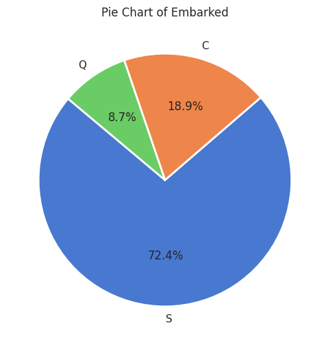

```python
# Get the value counts of the 'Embarked' column
embarked_counts = df['embarked'].value_counts()

# Create the pie plot
plt.figure(figsize=(8, 6))  # Adjust figure size as needed
plt.pie(embarked_counts, labels=embarked_counts.index, autopct='%1.1f%%', startangle=140, colors=sns.color_palette('muted') , wedgeprops = { 'linewidth' : 2, 'edgecolor' : 'white' })

# Add a title
plt.title('Pie Chart of Embarked')

# Show the plot
plt.show()
```

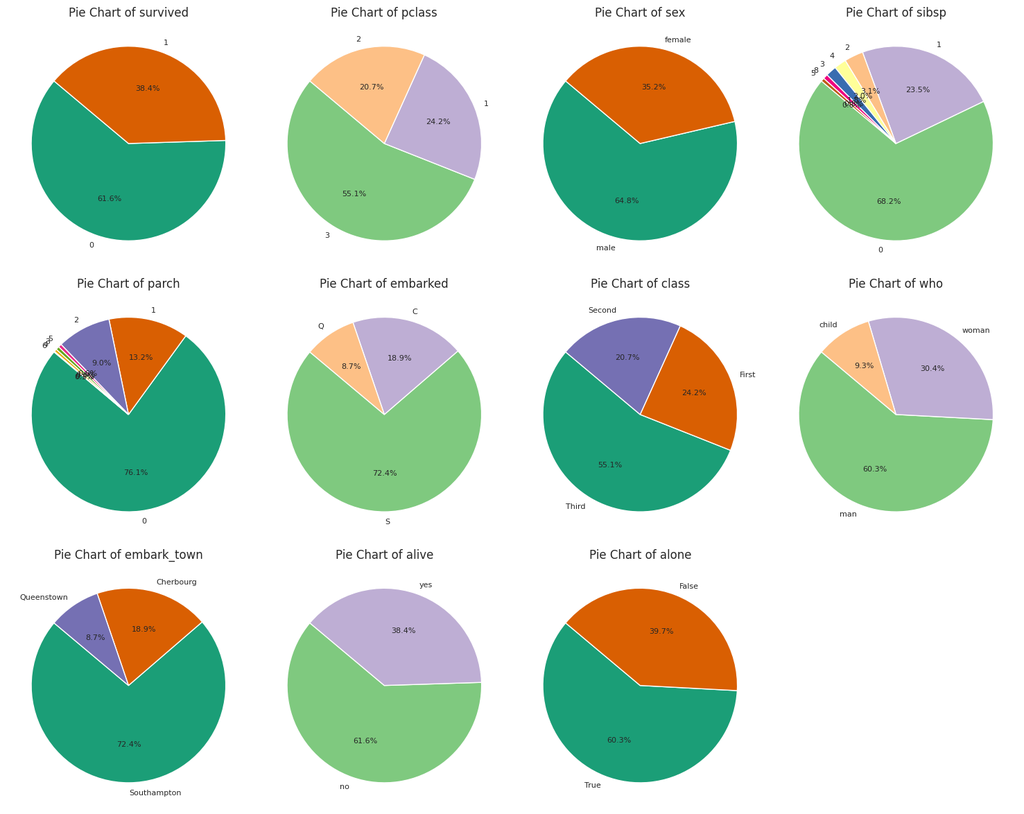

```python
# Define the columns to plot
columns_to_plot = ['survived', 'pclass', 'sex', 'sibsp', 'parch', 'embarked', 'class', 'who', 'embark_town', 'alive', 'alone']

# Define a list of color palettes
color_palettes = ['Dark2', 'Accent']

# Determine the number of rows and columns for the subplot grid
num_cols = 4
num_rows = (len(columns_to_plot) + num_cols - 1) // num_cols  # Ensure enough rows

# Create the subplots
fig, axes = plt.subplots(num_rows, num_cols, figsize=(15, 12))
axes = axes.flatten()

# Iterate through the columns and plot each one in a separate subplot
for i, col in enumerate(columns_to_plot):
    # Select the appropriate subplot axis
    ax = axes[i]

    # Get the value counts for the current column
    counts = df[col].value_counts()

    # Use a different color palette for each pie chart
    palette = color_palettes[i % len(color_palettes)]  # Cycle through palettes

    # Create the pie chart
    ax.pie(counts,
           labels=counts.index,
           autopct='%1.1f%%',
           startangle=140,
           colors=sns.color_palette(palette),
           textprops={'fontsize': 8})

    # Set the title for the subplot
    ax.set_title(f"Pie Chart of {col}")

# Remove any unused subplots
if len(columns_to_plot) < num_rows * num_cols:
    for j in range(len(columns_to_plot), num_rows * num_cols):
        fig.delaxes(axes[j])

# Adjust the layout to prevent overlapping titles/labels
plt.tight_layout()

# Show the plots
plt.show()
```

# 4. How to Interpret Pie plot :

Key Features to Look For :

- Slices: The pie chart is divided into slices, each representing a category.
- Slice Size: The size of each slice corresponds to the proportion or percentage of the whole that the category represents. Larger slices indicate larger proportions.
- Categories: Each slice is labeled with the category it represents.
- Percentages/Proportions: Pie charts often include percentages or proportions within each slice to show the relative contribution of each category.
- Colors: Different colors are used to distinguish between categories.

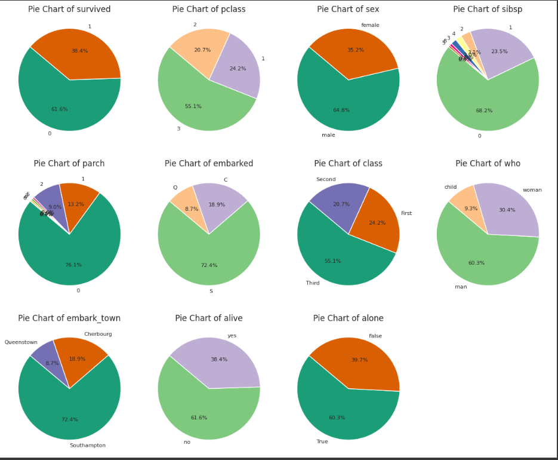

Pie Chart of Survived

- This chart shows the proportion of passengers who survived (1) and did not survive (0).
- A larger portion of the passengers did not survive (61.6%) compared to those who did (38.4%).

Pie Chart of pclass

- This chart shows the distribution of passengers across passenger classes. The majority of passengers were in third class (55.1%), followed by first class (24.2%) and second class (20.7%).

Pie Chart of sex

Pie Chart of sibsp

- This chart shows the distribution of passengers by the number of siblings/spouses they had aboard.
- A large portion of the passengers had no siblings or spouses (68.2%), while around 23.5% had one sibling/spouse.

Pie Chart of parch

- This chart shows the distribution of passengers by the number of parents/children they had aboard.
- The majority of the passengers had no parents or children (76.1%).

Pie Chart of embarked

- This chart shows the distribution of passengers by their port of embarkation. Most passengers embarked at Southampton (72.4%), followed by Cherbourg (18.9%) and Queenstown (8.7%).

Pie Chart of class

- This chart shows the distribution of passengers by passenger class ( повторяет Pie Chart of pclass).
- The majority of passengers were in the third class (55.1%), followed by the first class (24.2%) and second class (20.7%).

Pie Chart of who

- This chart shows the distribution of passengers by demographic category. Most passengers were men (60.3%), followed by women (30.4%), and children (9.3%).

Pie Chart of embark_town

- This chart shows the distribution of passengers by their embarkation town (повторяет Pie Chart of embarked).
- Most passengers embarked at Southampton (72.4%), followed by Cherbourg (18.9%), and Queenstown (8.7%).

Pie Chart of alive

- This chart shows the distribution of passengers by survival status (повторяет Pie Chart of survived).
- A larger portion of the passengers did not survive (61.6%) compared to those who did (38.4%).

Pie Chart of alone

- This chart shows the distribution of passengers by whether they were traveling alone.
- More passengers were traveling alone (60.3%) than those who were not (39.7%).